# Homework 5

Sricharraan Ramaswamy

09/03/2022

```r
load("lattice.Rdata")
head(hamster)
```

```
##       lung    heart    liver     spleen   kidney    testes
## 1 0.969500 1.352002 8.185496 0.22550020 1.348003 0.3415002
## 2 1.141003 1.499403 8.544507 0.27049980 1.322103 0.4170000
## 3 0.872000 1.268503 6.823009 0.04999999 0.897001 1.2200020
## 4 0.739900 1.270203 9.067509 0.11299980 1.278003 0.8145000
## 5 1.139302 1.496203 9.621993 0.11980000 1.415003 1.1568030
## 6 1.125603 1.191403 9.743209 0.13929990 1.340502 1.3599010
```

```r
library(devtools)
```

```r
install_github("vqv/ggbiplot")
```

```
## Skipping install of 'ggbiplot' from a github remote, the SHA1 (7325e880) has not changed since last install.
##   Use `force = TRUE` to force installation
```

```r
library(ggbiplot)
library(ade4)
library(viridis)
summary(hamster)
```

```
##       lung            heart            liver            spleen
##  Min.   :0.3216   Min.   :0.4134   Min.   : 1.626   Min.   :0.0293
##  1st Qu.:0.6220   1st Qu.:0.8039   1st Qu.: 3.262   1st Qu.:0.0657
##  Median :0.8416   Median :1.0690   Median : 6.439   Median :0.0896
##  Mean   :0.8457   Mean   :1.0581   Mean   : 6.299   Mean   :0.1035
##  3rd Qu.:1.0260   3rd Qu.:1.2763   3rd Qu.: 8.307   3rd Qu.:0.1283
##  Max.   :1.6521   Max.   :1.8390   Max.   :15.492   Max.   :0.2959
##      kidney           testes
##  Min.   :0.8199   Min.   :0.3082
##  1st Qu.:1.0751   1st Qu.:0.6387
##  Median :1.2291   Median :0.9761
##  Mean   :1.2256   Mean   :1.0900
##  3rd Qu.:1.3642   3rd Qu.:1.4862
##  Max.   :1.7381   Max.   :2.4244
```

```r
ham_scale_1 = prcomp(hamster , scale. = FALSE)
ham_scale_1$rotation[,1:2]
```

```
##                PC1           PC2
## lung   -0.04844187 -1.400244e-02
## heart  -0.07583873 -1.194474e-01
## liver  -0.99409891 -2.013637e-02
## spleen -0.01213091 -1.658741e-05
## kidney -0.04990582 -4.195610e-02
## testes -0.03211681  9.916504e-01
```

```r
ham_scale_2 = prcomp(hamster , scale. = TRUE)
ham_scale_2$rotation[,1:2]
```

```
##                PC1         PC2
## lung   -0.40885549 -0.05704641
## heart  -0.46129490 -0.20800130
## liver  -0.48564405  0.08125510
## spleen -0.41489143  0.09751789
## kidney -0.45260553 -0.09380103
## testes -0.08489638  0.96362358
```

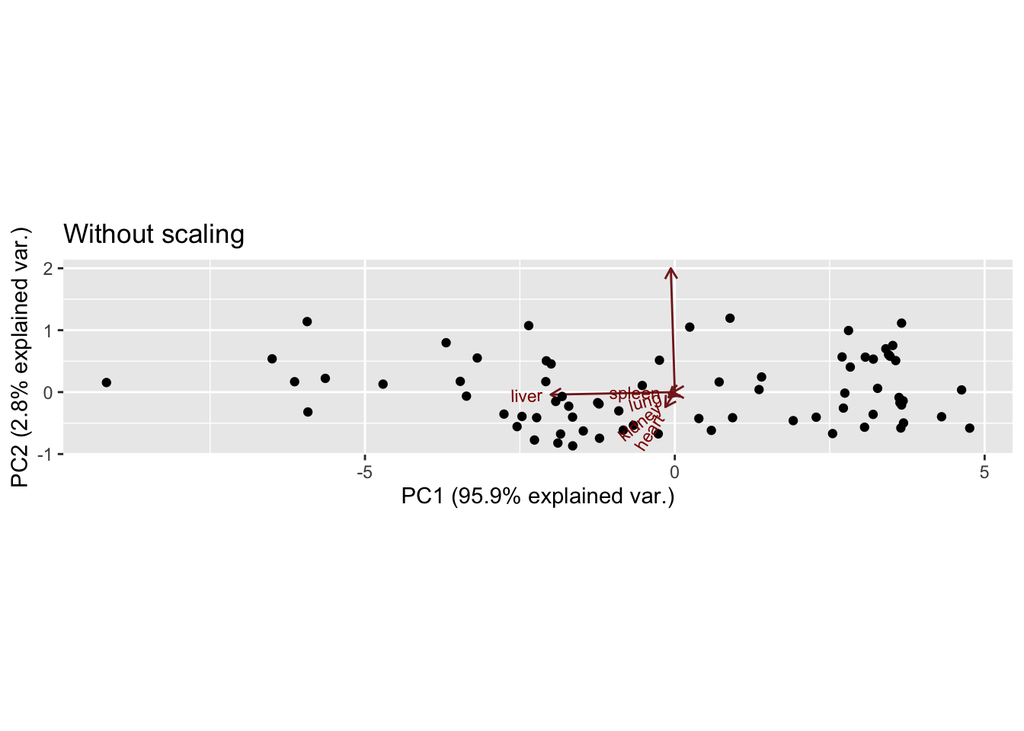

```r
ggbiplot(ham_scale_1,scale = 0) + ggtitle("Without scaling")
```

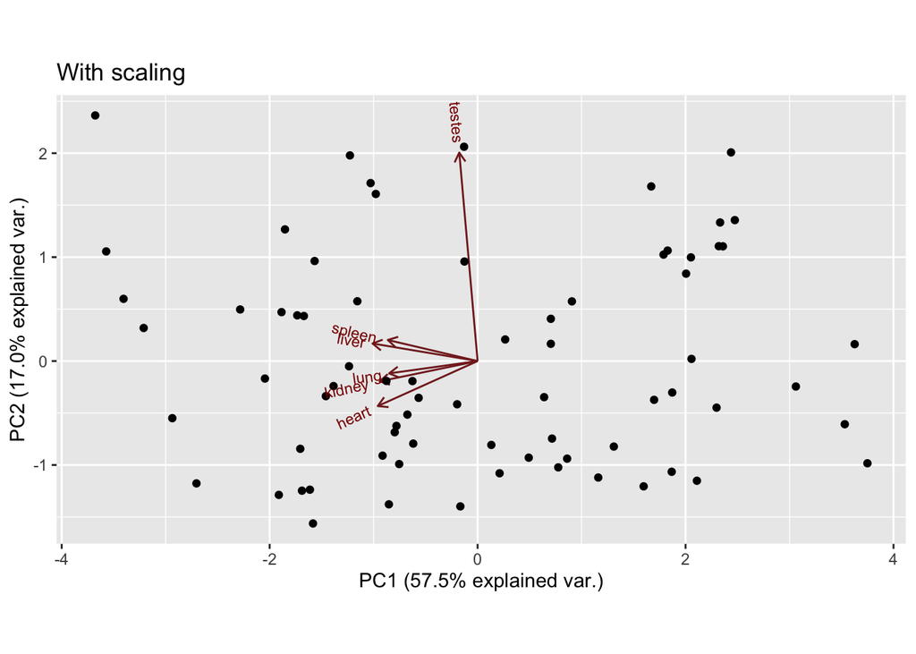

```r
ggbiplot(ham_scale_2,scale = 0) + ggtitle("With scaling")
```

The principal-axes capture just the variance of the features ‘Liver’ and ‘Testes,’ which have the most variation in the data set, when PCA is applied to unscaled log-transformed weights. These two axis have relatively big eigenvalues. The biplot’s other principal-axes (designated as combinations of organ-weights) appear congested.

The eigenvalues for ‘Liver’ and ‘Testes’ no longer dominate the principal axes thanks to feature-scaling. In addition, the data appears to be projected more accurately onto the dimensions with great variance.

Therefore, in this instance the one which is scaled is giving more accurate results than the one without scaling

```r
word_freq <- read.csv("http://jfukuyama.github.io/teaching/stat670/assignments/nyt_articles.csv")
```

```r
unique(word_freq$class.labels)
```

```
## [1] "art"   "music"
```

```r
which(apply(word_freq, 2, var)==0)
```

```
##   of  the
## 2665 3971
```

```r
drops <- c("of","the","art")
word_freq <- word_freq[ , !(names(word_freq) %in% drops)]
```

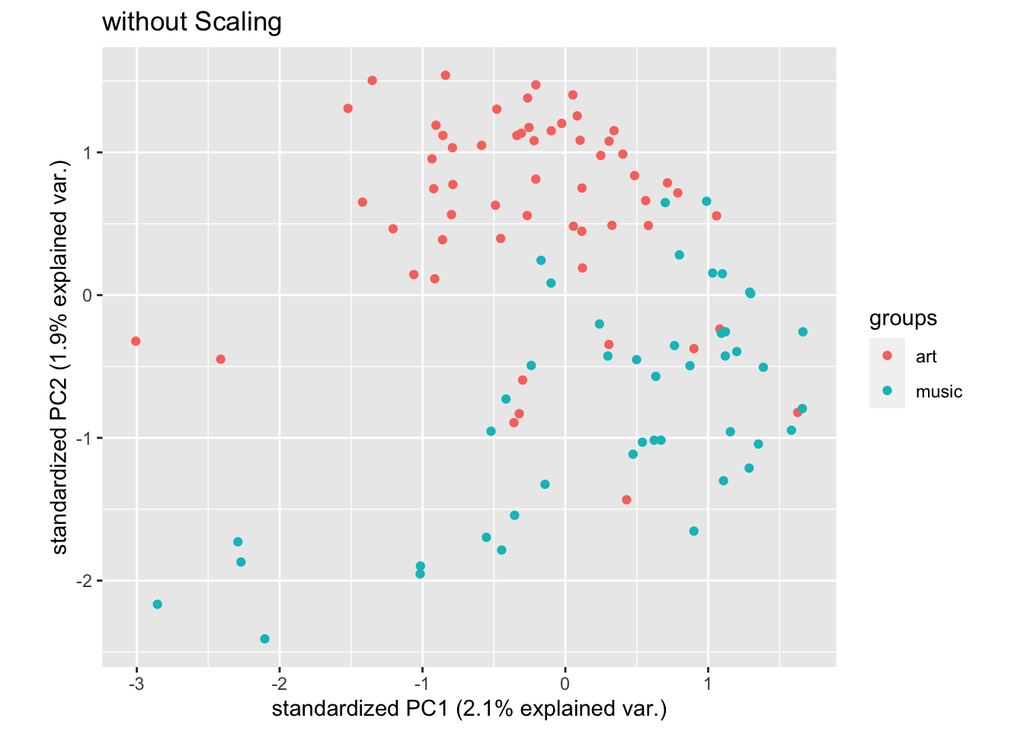

```r
word_freq_1 = prcomp(word_freq[-1] , scale. = FALSE, center = TRUE)
word_freq_2 = prcomp(word_freq[-1] , scale. = TRUE, center = TRUE)
df1 = data.frame(word_freq_1$x)
df1$class.labels <- word_freq$class.labels
df2 = data.frame(word_freq_2$x)
df2$class.labels <- word_freq$class.labels

ggbiplot(word_freq_1, scale = 1, var.axes = FALSE, groups = df1$class.labels) + ggtitle("without Scaling")
```

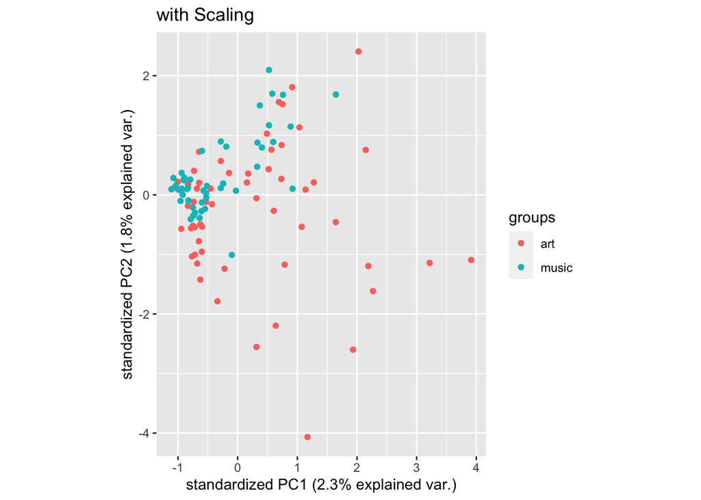

```r
ggbiplot(word_freq_2, scale = 1, var.axes = FALSE, groups = df2$class.labels) + ggtitle("with Scaling")
```

The scatterplot of points projected on the principal axes demonstrates a substantial separation between ‘art’ and’music’ articles when the data is not scaled. The eigenvalue of PC-2 of’music’ articles is tiny, but PC-2 of ‘art’ articles is huge. When the dataset is scaled, the result is a more congested view.

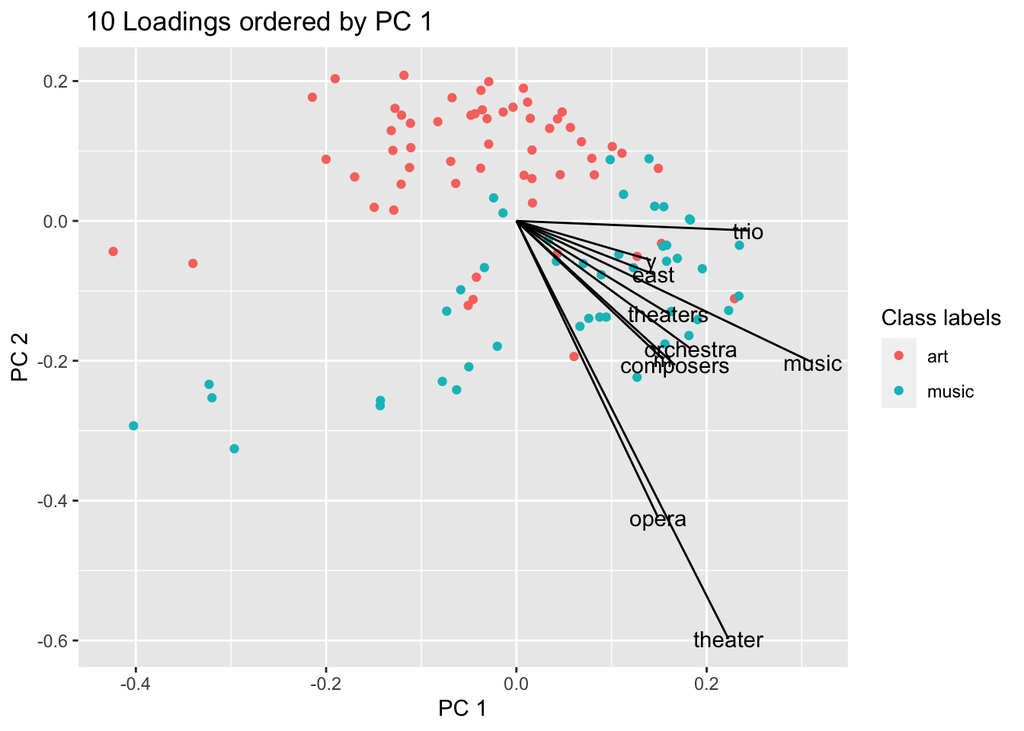

```r
word_freq_1 = prcomp(word_freq[-1] , scale. = FALSE, center = TRUE)

n_loadings <- 10
loadings <- data.frame(word_freq_1$rotation[,1:2])
loadings_0 <- loadings[order(-loadings$PC1),][1:n_loadings,]
loadings_1 <- loadings[order(-loadings$PC2),][1:n_loadings,]

ggplot() + geom_point(aes(x=PC1, y=PC2, color=class.labels), data = df1) + geom_segment(data=loadings_0,aes(xend=PC1*3, yend=PC2*3, x=0, y=0)) + geom_text(data=loadings_0, aes(x=PC1*3, y=PC2*3, label=row.names(loadings_0))) + xlab("PC 1") + ylab("PC 2") + ggtitle(" 10 Loadings ordered by PC 1") + scale_color_discrete('Class labels')
```

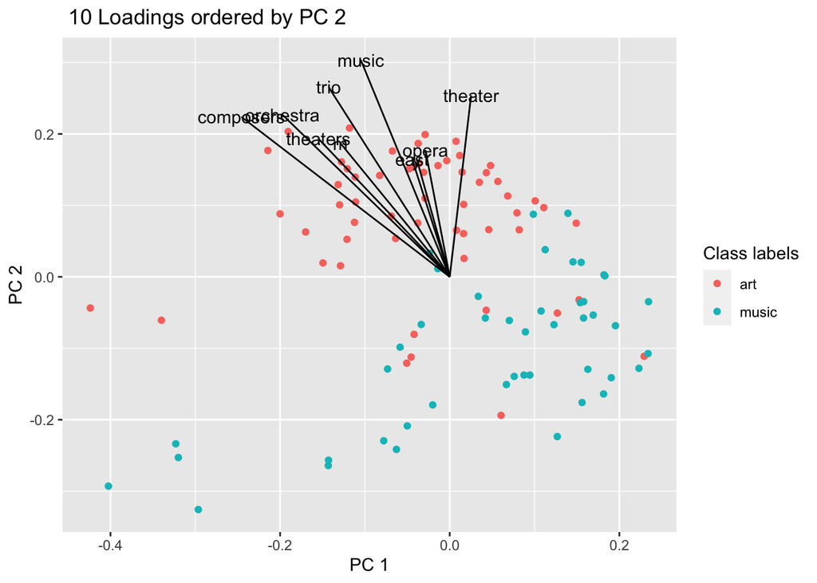

```r
ggplot() + geom_point(aes(x=PC1, y=PC2, color=class.labels), data = df1) + geom_segment(data=loadings_1,aes(xend=PC1*3, yend=PC2*3, x=0, y=0)) + geom_text(data=loadings_1, aes(x=PC1*3, y=PC2*3, label=row.names(loadings_0))) + xlab("PC 1") + ylab("PC 2") + ggtitle(" 10 Loadings ordered by PC 2") + scale_color_discrete('Class labels')
```

The words classified as’music’ articles contribute more to the largest loadings on PC 1. As a result, PC 1 now controls the majority of the ‘music’ articles.